# HW3

Allen Ho

7/20/2019

## Crawler

Here’s the code of ptt crawler. I will just display the code here and used load its output from ./data since it takes a lot of to run.

```r
library(dplyr)
library(bitops)
library(httr)
library(RCurl)
library(XML)
library(tm)
library(tmcn)
library(NLP)
library(stringr)
setwd('~/Documents/DSP/Data_Science_Programming/crawler/ptt')

boardname <- 'studyabroad'
start_page <- 1
end_page <- 1567
group_by <- 'month'

ptt_prefix <- 'https://www.ptt.cc'
ptt_ntu_prefix <- paste0( 'https://www.ptt.cc/bbs/', boardname, '/index' )
output_path <- paste0( './output/', boardname, '_', start_page, '_', end_page, '.csv' )

dir.create( paste0( './output/group_by_', group_by, '/', boardname ), showWarning=F )
urls <- function( page_num ) {
    paste0( page_num, ' (', start_page, ' to ', end_page, ')' ) %>% print
    paste0( ptt_ntu_prefix, page_num, '.html' ) %>%
        GET( set_cookies( `over18`="1" ) ) %>% htmlParse() %>%
        xpathSApply( "//div[@class='title']/a[@href]", xmlAttrs )
}
urls <- sapply( start_page:end_page, urls ) %>% unlist
get_time <- function( str ) {
    t <- strsplit( str, split=' ', fixed=T )[[1]]
    c(t[5], t[2], t[3], t[4]) %>% return
}
get_post <- function(str) {
    str %>% str_replace_all( '^.+\n', '' ) %>%
    str_replace_all( '\n\n\\-\\-\n(.|\n)*$', '' ) %>% return
}
get_text <- function( url ) {
    html <- paste0( ptt_prefix, url ) %>% GET( set_cookies( `over18`="1" ) ) %>% htmlParse()
    timestamp <- xpathSApply( html, "//span[@class='article-meta-value']", xmlValue )[4]
    timestamp <- gsub( "  ", " 1", timestamp ) %>% get_time %>% print
    content <- xpathSApply( html, "//div[@id='main-content']", xmlValue )
    post <- get_post( content )
    comment <- xpathSApply( html, "//span[@class='f3 push-content']", xmlValue ) %>% unlist() %>% paste( collapse='' )
    content <- paste( post, comment )
    hour <- strsplit( timestamp[4], split=':', fixed=T )[[1]][1] %>% print
    month <- timestamp[2]
    file_name <- paste0( './output/group_by_', group_by, '/', boardname, '/', month, '.txt' )
    write( content, file_name, append=T )
}
sapply( urls, get_text )
```

Load the documents.

```r
doc <- Corpus( DirSource('./data/studyabroad') ) %>%
    tm_map( removePunctuation ) %>%
    tm_map( removeNumbers ) %>%
    tm_map( function(word) {
        gsub( "[A-Za-z0-9]", "", word )
    })
```

## Analysis

Here’s the code that analyze the text of each month on ptt-studyabroad.

```r
cutter <- worker()

# add some new words
new_words <- read.csv( './data/new_user_word.csv', header=T )
new_user_word( cutter, as.character(new_words$word), as.character(new_words$pos) )
```

```
## [1] TRUE
```

```r
# create a function that split strins into words
segments <- function(d) {
    seg <- segment( d[[1]], cutter )
    chosen <- which( nchar(seg) > 1 )
    seg[chosen] %>% return
}
segments <- lapply( doc, segments )
```

count the words, create the `data.frame` of term-document matrix `tdm`, and turn it into a matrix (with words as row names and month as column names)

```r
tokens <- function( word ) { as.data.frame( table( word ) ) }
tokens <- lapply( segments, tokens ) #a list of vector

# combine the vector of each document (in the list) into a matrix
tdm <- tokens[[1]]
n <- length( segments )
for( id in 2:n) {
    tdm <- merge( tdm, tokens[[id]], by='word', all=T )
}
#colnames( tdm ) <- gsub( '.txt', '',colnames( tdm ) )

# change all the "NA" into 0
tdm[is.na(tdm)] <- 0

# turn tdm into a matrix and rename columns and rows
row_name <- tdm$word
col_name <- gsub( '.txt', '', names(doc) )
tdm <- as.matrix( tdm[,2:(n+1)] )
colnames( tdm ) <- col_name
rownames( tdm ) <- row_name
head( tdm )
```

```
##          Apr Aug Dec Feb Jan Jul Jun Mar May Nov Oct Sep
## 一一      40  14  12  25  13  22  28  54  30  19  12   8
## 一一列舉   2   0   1   1   0   1   0   0   2   0   0   0
## 一一對應   1   0   0   0   0   0   0   0   0   0   0   0
## 一丁點     4   2   2   0   3   1   0   2   2   0   0   1
## 一三五     1   3   0   1   0   1   0   0   0   0   0   0
## 一上       7   1   1   6   7   5   2  12   4   7   1   2
```

calculate `tf`, `idf`, and then `tfidf`.

I modified the formula of idf since many of the important words appear in every month. If I use the original n as denominator, the frequency of these words will become zero.

```r
tf <- apply( tdm, 2, function(c){c/sum(c)} )
idf <- function( word ) { log2( (n+0.5) / nnzero(word) ) }
idf <- apply( tdm, 1, idf )
tfidf <- apply( tf, 2, function(r){r*idf} )
head( tfidf )
```

```
##                   Apr          Aug          Dec          Feb          Jan
## 一一     2.493989e-06 1.977294e-06 1.655976e-06 3.028726e-06 1.756182e-06
## 一一列舉 2.799005e-06 0.000000e+00 3.097504e-06 2.719312e-06 0.000000e+00
## 一一對應 3.857688e-06 0.000000e+00 0.000000e+00 0.000000e+00 0.000000e+00
## 一丁點   2.726558e-06 3.088113e-06 3.017331e-06 0.000000e+00 4.430650e-06
## 一三五   1.740322e-06 1.182659e-05 0.000000e+00 3.381543e-06 0.000000e+00
## 一上     4.364481e-07 1.412353e-07 1.379980e-07 7.268941e-07 9.456363e-07
##                   Jul          Jun          Mar          May          Nov
## 一一     3.073448e-06 3.663283e-06 3.799538e-06 2.852639e-06 2.535656e-06
## 一一列舉 3.135756e-06 0.000000e+00 0.000000e+00 4.268691e-06 0.000000e+00
## 一一對應 0.000000e+00 0.000000e+00 0.000000e+00 0.000000e+00 0.000000e+00
## 一丁點   1.527296e-06 0.000000e+00 1.538463e-06 2.079102e-06 0.000000e+00
## 一三五   3.899404e-06 0.000000e+00 0.000000e+00 0.000000e+00 0.000000e+00
## 一上     6.985109e-07 2.616631e-07 8.443419e-07 3.803519e-07 9.341892e-07
##                   Oct          Sep
## 一一     1.719448e-06 1.312932e-06
## 一一列舉 0.000000e+00 0.000000e+00
## 一一對應 0.000000e+00 0.000000e+00
## 一丁點   0.000000e+00 1.794206e-06
## 一三五   0.000000e+00 0.000000e+00
## 一上     1.432874e-07 3.282329e-07
```

find the top 6 words of each month (with `tfidf` value), and find the top 8 words that appears the most.

```r
# grab the top 10 words and count the top 8 words
top <- function( col ) { rownames(tfidf)[order(-col)][1:6] }
top <- apply( tfidf, 2, top ) %>% print %>%
    as.matrix() %>%
    table() %>%
    as.data.frame()
```

```
##      Apr    Aug    Dec    Feb    Jan    Jul    Jun    Mar    May    Nov
## [1,] "申請" "可以" "學校" "信售" "學校" "可以" "可以" "學校" "可以" "學校"
## [2,] "學校" "申請" "申請" "學校" "可以" "申請" "學校" "申請" "學校" "申請"
## [3,] "可以" "學校" "可以" "申請" "申請" "學校" "申請" "可以" "申請" "可以"
## [4,] "自己" "美國" "自己" "可以" "自己" "美國" "美國" "恭喜" "自己" "自己"
## [5,] "恭喜" "自己" "沒有" "恭喜" "美國" "自己" "自己" "自己" "美國" "如果"
## [6,] "所以" "沒有" "美國" "交售" "沒有" "如果" "沒有" "所以" "所以" "美國"
##      Oct    Sep
## [1,] "申請" "可以"
## [2,] "可以" "學校"
## [3,] "學校" "申請"
## [4,] "狄邦" "美國"
## [5,] "美國" "自己"
## [6,] "如果" "如果"
```

```r
top_word <- top[order(-top$Freq),][1:8,1] %>% as.character() %>% print
```

```
## [1] "可以" "學校" "申請" "自己" "美國" "如果" "沒有" "恭喜"
```

```r
# arrange months
months <- c( 'Jan', 'Feb', 'Mar', 'Apr', 'May', 'Jun',
            'Jul', 'Aug', 'Sep', 'Oct', 'Nov', 'Dec' )
```

plot the numbers of the top 8 words vs month (using `tdm`)

```r
# reshape top8 to plot
top_plot <- tdm[top_word,months] %>% melt
head( top_plot )
```

```
##   Var1 Var2 value
## 1 可以  Jan  4830
## 2 學校  Jan  5020
## 3 申請  Jan  4633
## 4 自己  Jan  3000
## 5 美國  Jan  2762
## 6 如果  Jan  2399
```

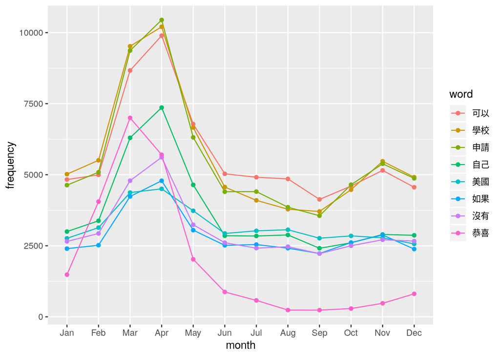

```r
names( top_plot ) <- c( 'word', 'month', 'frequency' )
ggplot( data=top_plot, aes( x=month, y=frequency, group=word, colour=word ) ) +
    geom_line() +
    geom_point()
```

There’s little information in this graph because the number of words mainly just follow the total amount of text.

Now we plot the frequency of the top 8 words vs month (using `tf`).

```r
# reshape top8 to plot
top_plot <- tf[top_word,months] %>% melt
head( top_plot )
```

```
##   Var1 Var2       value
## 1 可以  Jan 0.011079100
## 2 學校  Jan 0.011514924
## 3 申請  Jan 0.010627219
## 4 自己  Jan 0.006881428
## 5 美國  Jan 0.006335502
## 6 如果  Jan 0.005502849
```

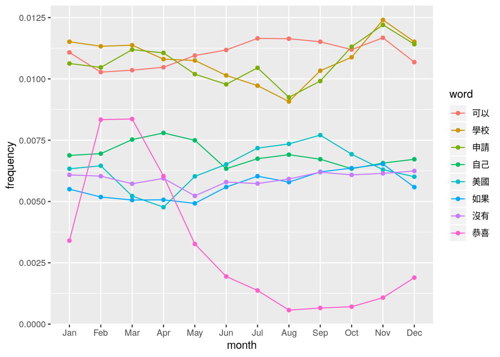

```r
names( top_plot ) <- c( 'word', 'month', 'frequency' )
ggplot( data=top_plot, aes( x=month, y=frequency, group=word, colour=word ) ) +
    geom_line() +
    geom_point()
```

According to the graph, the word “恭喜” has a peak around Feb and Mar. Maybe it’s because the result of applications usually come out in that period.

plot the amount of text (file size) of each month.

```r
filenames <- as.array( paste0( './data/studyabroad/', months, '.txt' ) )
sizes <- apply( filenames, 1, file.size ) / 1024
size_plot <- data.frame( month=months, size=sizes )
size_plot$month <- factor( size_plot$month, levels=months )
head( size_plot )
```

```
##   month      size
## 1   Jan  4747.933
## 2   Feb  5147.848
## 3   Mar  8939.830
## 4   Apr 10132.600
## 5   May  6562.883
## 6   Jun  4659.122
```

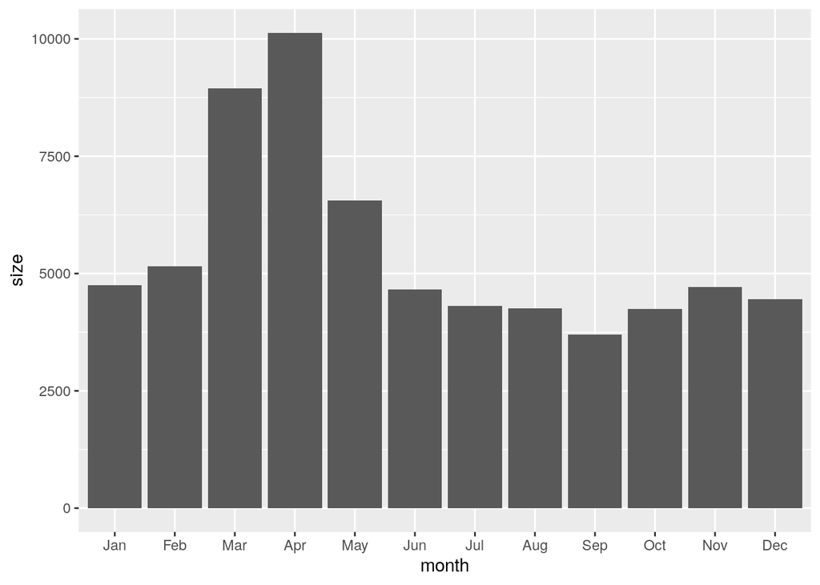

```r
ggplot( data=size_plot, aes( x=month, y=size ) ) +
    geom_bar( stat='identity' )
```

I have some trouble when trying to trying the important words in all the text. The algorithm of tfidf assume that, if a word appears in many documents, then it is not very important. But, since I divide all text (from 2005 to now) into 12 parts, some important words might appear in every part (such as “學校”, “申請”, “美國”). Therefore, they will be considered less important along with some words like “可以”, “如果”, “沒有”, while their frequency actually vary in different months.